# Задание 6. Показатели магазинов

Дмитрий Бодунов

29 октября 2016 г

Какие показатели или распределения на основе приведенных данных могут характеризовать работу магазинов? Привести примеры, расчеты. Сделать выводы.

С точки зрения компании основными показателями магазинов являются финансовые показатели - оборот, прибыль, чистая прибыль, EBITDA и пр. Кроме оборота данных для расчета показателей - нет.

В качестве показателей, которые характеризуют качество работы магазинов можно рассматривать загруженность касс, наличие товара на полках, продажа алкоголя после установленного времени (продавец отпускает товар вечером, но пробивает алкоголь утром следующего дня).

Рассмотрим в качестве примера скорость обслуживания магазинами покупателей. По информации из чеков можно определить загруженность касс и необходимость привлечения дополнительных кассиров.

Сначала рассчитаем максимальное количество касс на каждом магазине на основании продаж, сделанных в одном магазине, практически единовременно. В результата получим следующее распределение:

| Номер магазина | Количество касс |
| --- | --- |
| 956 | 3 |
| 958 | 2 |
| 961 | 2 |
| 974 | 2 |
| 980 | 2 |
| 999 | 3 |
| 1053 | 2 |
| 1082 | 2 |
| 1094 | 2 |
| 1122 | 2 |
| 1530 | 2 |
| 1534 | 2 |
| 1544 | 2 |
| 1574 | 2 |
| 1579 | 3 |
| 1594 | 2 |
| 1596 | 2 |
| 1602 | 2 |
| 1609 | 2 |
| 1612 | 2 |
| 17096 | 2 |
| 17474 | 3 |
| 19009 | 2 |
| 20581 | 2 |
| 21761 | 3 |
| 22691 | 2 |
| 24605 | 2 |
| 25039 | 2 |
| 27220 | 2 |
| 29245 | 2 |

Рассмотрим распределение временных интервалов между чеками. Информация о кассах, на которых пробивали чеки, отсустует. Предполагая, что в магазинах большинство времени работает одна касса, попробуем найти требуемое распределение. Данное предположение можно сделать на основании предыдущей информации о том, что максимальное количество одновременно используемых касс не превышает 3 (если бы касс было 10, тогда вероятность того что в основном работает только одна очень мала).

Сразу построим график *десятичного логарифма* интервала времени между чеками в магазине.

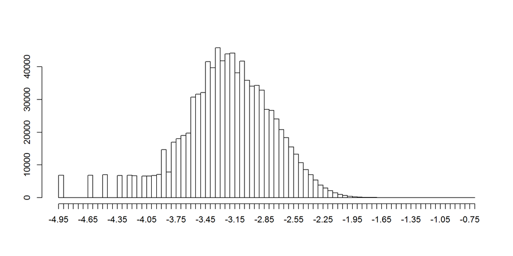

Из распределения видно, что максимум приходится на величину порядка -3.2, что соотвествует временному интервалу порядка одной минуты (00:01:00). Т.е. среднестатистического клиента кассир обслуживает за 1 минуту.

Также видно, что логарифм имеет похожее на нормальное распределение, поэтому найдем стандартное отклонение данной величины. Оно составляет порядка 0.5. Т.е. с вероятностью 95% логарифм времени обслуживания клиента не превышает -2.2, что соответствует 9 минутам (**00:09:00**).

Теперь рассмотрим интервал между пробиванием товаров на кассе. Построим график распределения интервала и график логарифма распределения интервала.

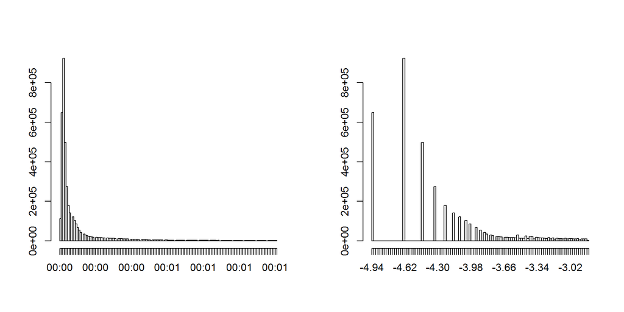

Из графиков видно, что чаще всего время между пробиванием товаров составляет 2-3 секунды, но среднее время заметно выше - около 10 секунд.

Также на графике логарифма можно заметить слабый всплеск в области -3.4, что соответствует времени порядка 30 секунд (00:00:30) и скорее всего соответсвует времени расчета покупателя.

На основании полученных данных можно следить за нагруженностью касс, например следующим образом.

Если в течение 9 минут подряд интервал между пробиванием товаров на кассе не превышает 30 секунд, то касса сильно нагружена и имеет смысл сигнализировать управляющему магазином об открытии дополнительных касс.